# Example Derivation of Regional Adjustment

PME

This notebook outlines as transparently as possible the derivation of regional adjustments to carbon stocks, the estimation of potential carbon stocks on agricultural land, and the resulting carbon gap.

Based on results, we recommend the top-down, stationary approach for developing regional adjustments to iSDA SOC stock predictions in agricultural lands. This follows the flowchart in Supplementary Figure 1. The steps are:

1. Evaluate the relationship between iSDA predictions and empirical measurements of SOC stocks, where iSDA predictions are based on iSDA predictions of both SOC concentrations and bulk density.
- *Inputs*: Sampled data; iSDA values at sampled locations.
- *Outputs*: Regression of empirical data vs iSDA predictions
2. Use this relationship to adjust iSDA SOC stocks.
- *Inputs*: iSDA SOC stocks
- *Outputs*: Map of adjusted iSDA SOC stocks
3. Identify edaphic and climatic factors that define soils with similar SOC- limiting properties – here, elevation and iSDA-predicted soil texture – through variable selection by LASSO regularized regression.
- *Inputs*: Adjusted iSDA SOC stocks and empirical soil properties at sample locations
- *Outputs*: A list of predictors
4. Use the selected factors to develop a quantile regression relationship between iSDA SOC stocks and the covariates at the threshold of choice - we used the 80th percentile, which thus represents an expected upper limit or potential of carbon stocks given soil covariates (we used the 80th percentile).
- *Inputs*: same as Step 3.
- *Outputs*: Quantile regression of adjusted iSDA SOC stocks vs predictors
5. Use this relationship to predict potential carbon stocks across the region of interest.
- *Inputs*: Adjusted SOC stocks, layers of other soil properties.
- *Outputs*: Map of potential SOC stocks
6. Calculate carbon gaps as the difference between current and potential stocks, with a floor of zero.
- *Inputs*: Derived maps of adjusted SOC stocks and potential SOC stocks
- *Outputs*: Map of carbon gaps

# Setup

## Critical Variables

```r
set_datum = 'epsg:4326'  # WGS84
set_projection = 'epsg:32736'  # utm 36S.

# output
overwrite = FALSE
# overwrite = TRUE
```

## Data sources

iSDA layers were downloaded individually from Zenodo - see the get_isda notebook. These were then combined with SRTM90 (elevation) from google earth engine and masked for land suitable for agriculture in Malawi based on Li et al (2017).

```r
# locations
in_dir = 'Data'
in_pt = 'Master Points.gpkg'

dir_spatial = 'Spatial' # in in_dir
in_isda = 'iSDA_combined_masked.tif'
# in_suit = 'LI_ETAL_2017_MW_AGRI_LAND_SUIT.tif'  # cropland suitability
in_mwi = "Malawi gadm36_MWI.gpkg"
# in_dem = "srtm90_MWI.tif"

out_dir = 'Results'
```

## Libraries

```r
libs = c(
  # Coding helpers
  'here',
  'magrittr',

  # spatial stuff
  'sf',
  'terra',
  'stars',

  # Other modeling
  'glmnet',
  'quantreg',

  # plotting
  'ggplot2',
  'rasterVis',
  'gridExtra'
)

# load
for (i in libs) {
  if (!require(i, character.only=TRUE)) {
    renv::install(i)
    require(i, character.only=TRUE)
  }}
# versions
sapply(libs, function(x) as.character(packageVersion(x))) %>%
  as.matrix %>%
  set_colnames(R.version.string)
```

```
##           R version 4.1.1 (2021-08-10)
## here      "1.0.1"
## magrittr  "2.0.3"
## sf        "1.0.8"
## terra     "1.6.7"
## stars     "0.5.6"
## glmnet    "4.1.4"
## quantreg  "5.93"
## ggplot2   "3.3.6"
## rasterVis "0.51.2"
## gridExtra "2.3"
```

### Custom Functions

```r
# calculate carbon stocks based on carbon concentration, bulk density, and depth
calc_stock = function(carbon, bulk_density, depth) {
  # units
  # carbon: decimal_percent (decimals, ex 1% = 0.01)
  # bulk density: g/cm3
  # depth: m
  # returns stock in Mg/ha
  bulk_density = bulk_density * 100^3 # convert to g/m3
  ha_volume = 10000 * depth # calc volume per 10000 m2 surface (1 ha)
  soil_mass = bulk_density * ha_volume / 1E6
  out = carbon * soil_mass

  return(out)
}

# use ggplot and rasterVis to plot a terra object.
ggmap = function(raster, fill='value', label=NULL) {
  require(rasterVis)
  out = gplot(raster) +
    geom_tile(aes_string(fill=fill)) +
    scale_fill_distiller(palette='YlGnBu',
                         direction=1,
                         na.value=NA) +
    coord_equal() +
    labs(fill=label) +
    labs(x=NULL,
         y=NULL) +
    theme_minimal()
  return(out)
}
```

## Load

### iSDA

```r
isda =  here(in_dir, dir_spatial, in_isda) %>%
  rast
summary(isda)
```

```
##     ISDA_TC         ISDA_SOC        ISDA_BD         ISDA_PH
##  Min.   : 6.39   Min.   : 3.48   Min.   :1.00    Min.   :4.80
##  1st Qu.:19.09   1st Qu.: 7.17   1st Qu.:1.33    1st Qu.:5.80
##  Median :23.53   Median : 8.03   Median :1.38    Median :6.00
##  Mean   :22.56   Mean   : 8.83   Mean   :1.36    Mean   :5.98
##  3rd Qu.:26.11   3rd Qu.:10.02   3rd Qu.:1.41    3rd Qu.:6.10
##  Max.   :53.60   Max.   :32.12   Max.   :1.53    Max.   :7.70
##  NA's   :77683   NA's   :77683   NA's   :77683   NA's   :77683
##    ISDA_SAND       ISDA_SILT       ISDA_CLAY       ELEVATION
##  Min.   :0.36    Min.   :0.06    Min.   :0.07    Min.   :  37.0
##  1st Qu.:0.58    1st Qu.:0.11    1st Qu.:0.19    1st Qu.: 626.0
##  Median :0.63    Median :0.13    Median :0.22    Median :1022.0
##  Mean   :0.62    Mean   :0.13    Mean   :0.23    Mean   : 915.8
##  3rd Qu.:0.67    3rd Qu.:0.14    3rd Qu.:0.25    3rd Qu.:1183.0
##  Max.   :0.81    Max.   :0.29    Max.   :0.42    Max.   :1962.0
##  NA's   :77683   NA's   :77683   NA's   :77683   NA's   :77676
##  ISDA_CSTOCK_NOW
##  Min.   : 9.96
##  1st Qu.:20.07
##  Median :22.79
##  Mean   :23.66
##  3rd Qu.:27.06
##  Max.   :64.23
##  NA's   :77683
```

This raster stack was combined with elevation data and masked to include only land suitable for agriuclture.

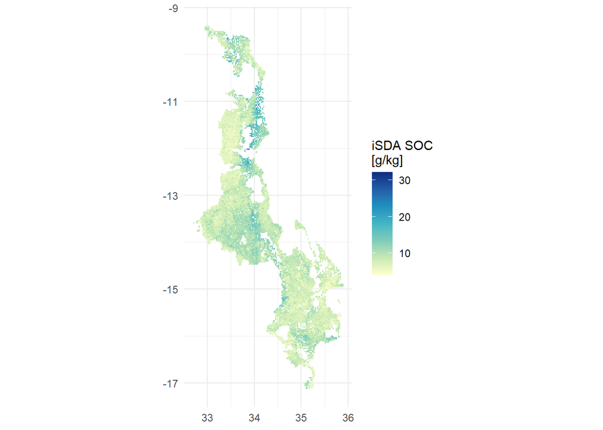

```r
ggmap(isda$ISDA_SOC, label='iSDA SOC\n[g/kg]')
```

### Point Data

```r
pt = here(in_dir, in_pt) %>%
  st_read
head(pt)
```

|  | SAMPLEID | EPA | YEAR | DISTRICT | TOTALC | POXC | TOTALN | PH | SAND | CLAY | SILT | SOILCLASS | CLASSCODE | ELEVATION | CGI | EVI | NDVI | SR | LST | PRECIP_DAILY | PRECIP_SUM | SLOPE | SLOPECLASS | FERTILITY | BULK_DENSITY | ISDA_TC | ISDA_SOC | ISDA_BD | ISDA_PH | … |
| --- | --- | --- | --- | --- | --- | --- | --- | --- | --- | --- | --- | --- | --- | --- | --- | --- | --- | --- | --- | --- | --- | --- | --- | --- | --- | --- | --- | --- | --- | --- |
| 1 | 1101h | Linthipe | 2016 | Dedza | 13.3350 | 340.48 | 0.09926 | 5.81 | 0.6507153 | 0.1811014 | 0.1681833 | sandy loam (SL) | SL | 1241 | 2.154771 | 0.1906607 | 0.3766085 | 3.154771 | 27.64361 | 4.510343 | 816.3721 | 1.0053580 | flat | h | 1.626667 | 23.53253 | 10.02318 | 1.36 | 5.9 | … |
| 2 | 1101l | Linthipe | 2016 | Dedza | 13.9610 | 321.28 | 0.09220 | 7.22 | 0.6115949 | 0.1809405 | 0.2074645 | sandy loam (SL) | SL | 1225 | 1.697885 | 0.2291199 | 0.4166497 | 2.697885 | 27.56258 | 4.730135 | 856.1544 | 0.6956893 | flat | l | NA | 26.11264 | 12.46374 | 1.36 | 6.1 | … |
| 3 | 1102h | Linthipe | 2016 | Dedza | 12.3810 | 324.62 | 0.09158 | 6.23 | 0.6246817 | 0.1719678 | 0.2033505 | sandy loam (SL) | SL | 1241 | 1.939438 | 0.1748126 | 0.3445461 | 2.939438 | 27.64361 | 4.510343 | 816.3721 | 1.0053580 | flat | h | 1.648333 | 23.53253 | 10.02318 | 1.34 | 6.0 | … |
| 4 | 1102l | Linthipe | 2016 | Dedza | 12.9220 | 359.68 | 0.09206 | 8.03 | 0.6454992 | 0.1705973 | 0.1839035 | sandy loam (SL) | SL | 1241 | 1.867568 | 0.1683161 | 0.3329472 | 2.867568 | 27.64361 | 4.510343 | 816.3721 | 1.0053580 | flat | l | 1.655000 | 23.53253 | 10.02318 | 1.36 | 6.4 | … |
| 5 | 1103h | Linthipe | 2016 | Dedza | 9.8118 | 180.44 | 0.07276 | 5.88 | 0.5641255 | 0.2267432 | 0.2091313 | sandy clay loam (SCL) | SCL | 1240 | 2.336816 | 0.2481087 | 0.4808046 | 3.336816 | 27.09206 | 4.510343 | 816.3721 | 1.2769034 | flat | h | NA | 23.53253 | 10.02318 | 1.32 | 5.8 | … |
| 6 | 1103l | Linthipe | 2016 | Dedza | 14.2560 | 468.52 | 0.09225 | 5.78 | 0.5644593 | 0.2435565 | 0.1919842 | sandy clay loam (SCL) | SCL | 1240 | 2.177106 | 0.2071758 | 0.4338979 | 3.177106 | 27.09206 | 4.510343 | 816.3721 | 1.2769034 | flat | l | NA | 23.53253 | 11.18249 | 1.32 | 5.8 | … |

CGI, EVI, NDVI, SR, and LST are all MODIS/LANDSAT. Only LST is used.

# Adjust iSDA SOC stocks

## Calculate estimated SOC stocks, 0-20cm depth

*Units*

- Bulk density: g ml<sup>-3</sup>
- Soil Carbon: g kg<sup>-1</sup>
- Depth: 20 cm
- Output units: Mg ha<sup>-1</sup>

```r
calc_stock = function(carbon, bulk_density, depth) {
  # units
  # carbon: decimal_percent (decimals, ex 1% = 0.01)
  # bulk density: g/cm3
  # depth: m
  # returns stock in Mg/ha
  bulk_density = bulk_density * 100^3 # convert to g/m3
  ha_volume = 10000 * depth # calc volume per 10000 m2 surface (1 ha)
  soil_mass = bulk_density * ha_volume / 1E6
  out = carbon * soil_mass

  return(out)
}


pt$ISDA_CSTOCK =
  with(pt,
       calc_stock(ISDA_SOC/1000,  # convert to fraction (decimal)
                  ISDA_BD,
                  0.2)
  )


isda$ISDA_CSTOCK = calc_stock(isda$ISDA_SOC/1000,
                              isda$ISDA_BD,
                              0.2)
```

Predict bulk density with earlier-derived pedotransfer function (or of choice)

```r
pt$BULK_DENSITY_PEDO = with(pt,
                            1.29 - 0.0072*TOTALC + .344*SAND)

pt$CSTOCK_NOW = with(pt,
                 calc_stock(TOTALC/1000,
                            BULK_DENSITY_PEDO,
                            0.2))
```

## Derive relationship

```r
isda_adjust = lm(CSTOCK_NOW ~ poly(ISDA_CSTOCK, 2), data=pt)
summary(isda_adjust)
```

```
##
## Call:
## lm(formula = CSTOCK_NOW ~ poly(ISDA_CSTOCK, 2), data = pt)
##
## Residuals:
##     Min      1Q  Median      3Q     Max
## -24.029  -4.923  -0.865   3.653  70.701
##
## Coefficients:
##                       Estimate Std. Error t value Pr(>|t|)
## (Intercept)            29.2952     0.2298 127.488  < 2e-16 ***
## poly(ISDA_CSTOCK, 2)1 420.1864     7.8509  53.521  < 2e-16 ***
## poly(ISDA_CSTOCK, 2)2  28.3471     7.8511   3.611 0.000319 ***
## ---
## Signif. codes:  0 '***' 0.001 '**' 0.01 '*' 0.05 '.' 0.1 ' ' 1
##
## Residual standard error: 7.799 on 1149 degrees of freedom
##   (8 observations deleted due to missingness)
## Multiple R-squared:  0.7144, Adjusted R-squared:  0.7139
## F-statistic:  1437 on 2 and 1149 DF,  p-value: < 2.2e-16
```

```r
pt$ISDA_CSTOCK_NOW = predict(isda_adjust, pt)
```

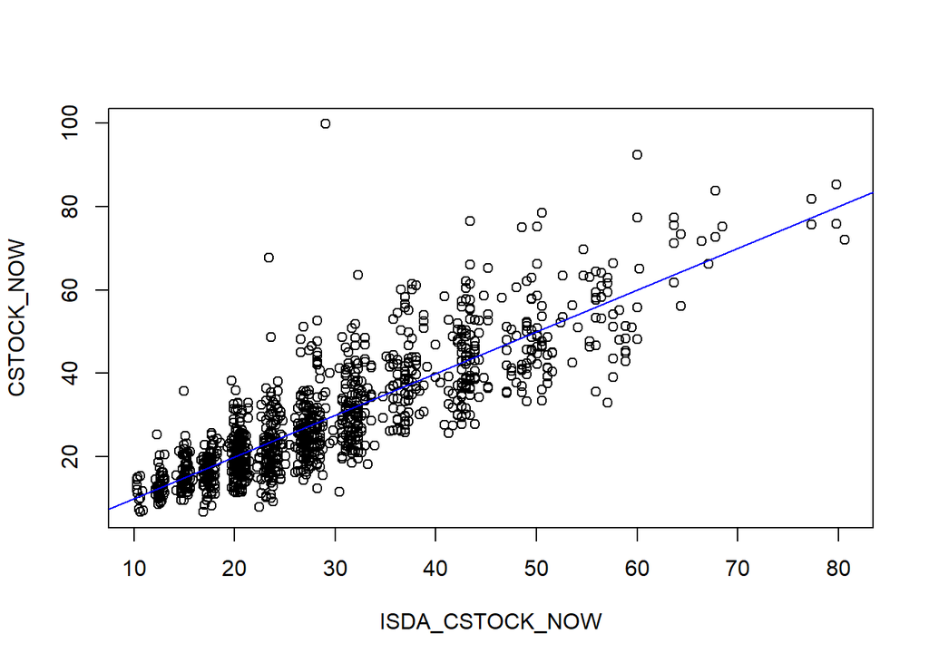

```r
with(pt, plot(ISDA_CSTOCK_NOW,
              CSTOCK_NOW))
abline(a=0, b=1, col='blue')
```

## Map

```r
adj_stocks = predict(isda,
                     isda_adjust) %>%
  set_names('CSTOCK_NOW')
```

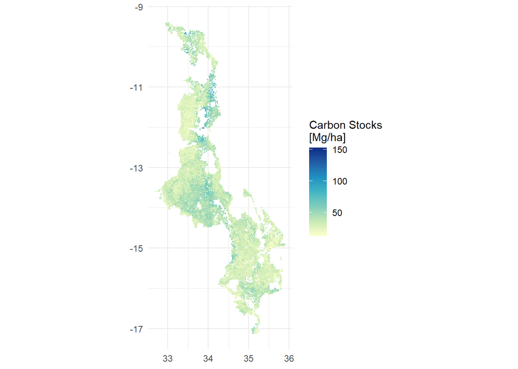

```r
ggmap(adj_stocks$CSTOCK_NOW, label='Carbon Stocks\n[Mg/ha]')
```

Spatially similar but with very different ranges to non-adjusted.

# Estimate Potentials

## Predictors

```r
# Generate matrices for glmnet
mm = model.frame(ISDA_CSTOCK_NOW ~
                   ISDA_SAND + ISDA_SILT + ISDA_CLAY + ELEVATION + LST + PRECIP_DAILY,
                 data=pt) %>%
  as.matrix
y = mm[, 1, drop=FALSE]
x = mm[, -c(1), drop=FALSE]

potential_predictors = cv.glmnet(x,
                                 y,
                                 alpha=.95) %>%
  coef(s='lambda.1se') %T>%
  print
```

```
## 7 x 1 sparse Matrix of class "dgCMatrix"
##                        s1
## (Intercept)   32.91447634
## ISDA_SAND    -30.19033667
## ISDA_SILT     22.69047978
## ISDA_CLAY     49.29163817
## ELEVATION      0.00624628
## LST            .
## PRECIP_DAILY   .
```

These are candidate predictors. In the manuscript we only kept those with statistical significance which we skip here for clarity. Note that sand, silt, and clay are highly collinear and thus only two are necessary.

## Derive Quantile Relationship to Estimate Potentials

At the 80th percentile.

```r
potentials_mod = rq(ISDA_CSTOCK_NOW ~ ISDA_SAND + ISDA_SILT + ISDA_CLAY,
                   data=pt,
                   tau=0.8)
```

## Predict

```r
adj_stocks$CSTOCK_80 =
  predict(isda,
          potentials_mod,
          type='none') %>%   # skip calculating errors for the demo.
  max(adj_stocks$CSTOCK_NOW) # if a location has more carbon than the 80th percentile, use that value.
```

## Map

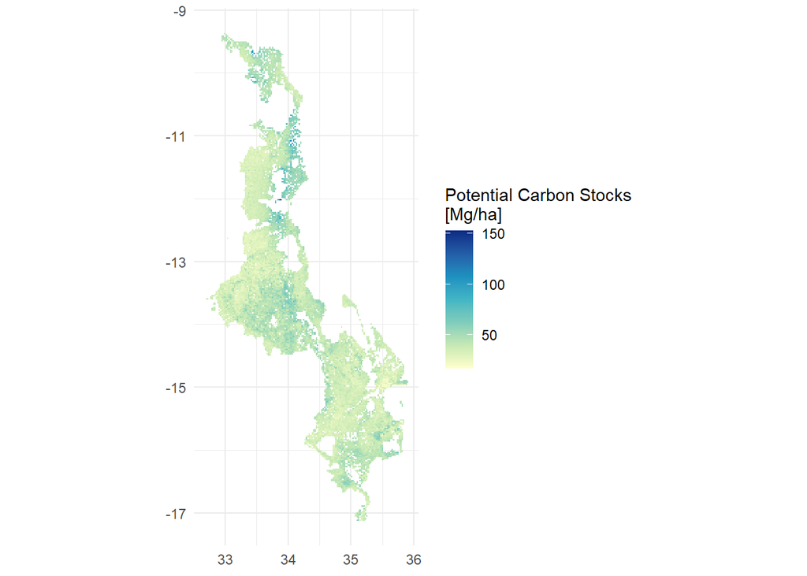

```r
ggmap(adj_stocks$CSTOCK_80,
      label='Potential Carbon Stocks\n[Mg/ha]')
```

```r
summary(adj_stocks)
```

```
##    CSTOCK_NOW       CSTOCK_80
##  Min.   : 10.38   Min.   : 17.51
##  1st Qu.: 27.92   1st Qu.: 33.36
##  Median : 33.26   Median : 38.41
##  Mean   : 35.44   Mean   : 39.91
##  3rd Qu.: 42.13   3rd Qu.: 44.74
##  Max.   :145.98   Max.   :145.98
##  NA's   :77683    NA's   :77683
```

# Calculate gap

```r
adj_stocks$CGAP = adj_stocks$CSTOCK_80 - adj_stocks$CSTOCK_NOW
```

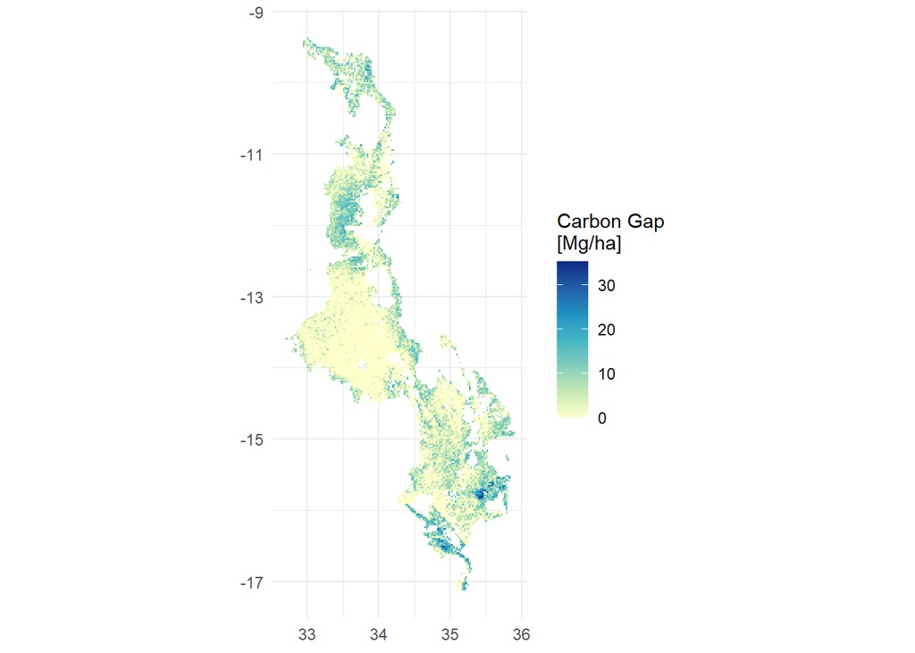

```r
ggmap(adj_stocks$CGAP, label='Carbon Gap\n[Mg/ha]')
```

THese are the estimated carbon gaps in agriucltural soils of Malawi.